# R Notebook

```r
library(tidyverse)
library(janitor)
library(infer)

books <- read_csv("data/books.csv")
books_tidy <- books %>%
  clean_names() %>%
  filter(!is.na(average_rating)) %>%
  rename(num_pages = number_num_pages) %>%
  glimpse()
```

```
Rows: 10,999
Columns: 10
$ book_id            <dbl> 1, 2, 3, 4, 5, 8, 9, 10, 12, 13, 14, 16, 18, 21, 22, 23, 24, 25, 26, 27, 28, 29, 30, 31, 32, 34, 35, 36, 37, 38, 40, 45, 50, 51,…
$ title              <chr> "Harry Potter and the Half-Blood Prince (Harry Potter  #6)", "Harry Potter and the Order of the Phoenix (Harry Potter  #5)", "Ha…
$ authors            <chr> "J.K. Rowling-Mary GrandPré", "J.K. Rowling-Mary GrandPré", "J.K. Rowling-Mary GrandPré", "J.K. Rowling", "J.K. Rowling-Mary Gra…
$ average_rating     <dbl> 4.56, 4.49, 4.47, 4.41, 4.55, 4.78, 3.69, 4.73, 4.38, 4.38, 4.22, 4.22, 4.38, 4.20, 3.43, 3.88, 4.07, 3.90, 3.83, 3.87, 3.92, 3.…
$ isbn               <chr> "0439785960", "0439358078", "0439554934", "0439554896", "043965548X", "0439682584", "0976540606", "0439827604", "0517226952", "0…
$ isbn13             <chr> "9780439785969", "9780439358071", "9780439554930", "9780439554893", "9780439655484", "9780439682589", "9780976540601", "97804398…
$ language_code      <chr> "eng", "eng", "eng", "eng", "eng", "eng", "en-US", "eng", "eng", "eng", "eng", "eng", "en-US", "eng", "eng", "eng", "eng", "eng"…
$ num_pages          <dbl> 652, 870, 320, 352, 435, 2690, 152, 3342, 815, 815, 215, 6, 815, 544, 55, 256, 335, 304, 299, 254, 324, 270, 1728, 1184, 1137, 3…
$ ratings_count      <dbl> 1944099, 1996446, 5629932, 6267, 2149872, 38872, 18, 27410, 3602, 240189, 4416, 1222, 2801, 228522, 6993, 2020, 68213, 47490, 43…
$ text_reviews_count <dbl> 26249, 27613, 70390, 272, 33964, 154, 1, 820, 258, 3954, 408, 253, 192, 8840, 470, 124, 4077, 2153, 2146, 2127, 3159, 1986, 1536…
```

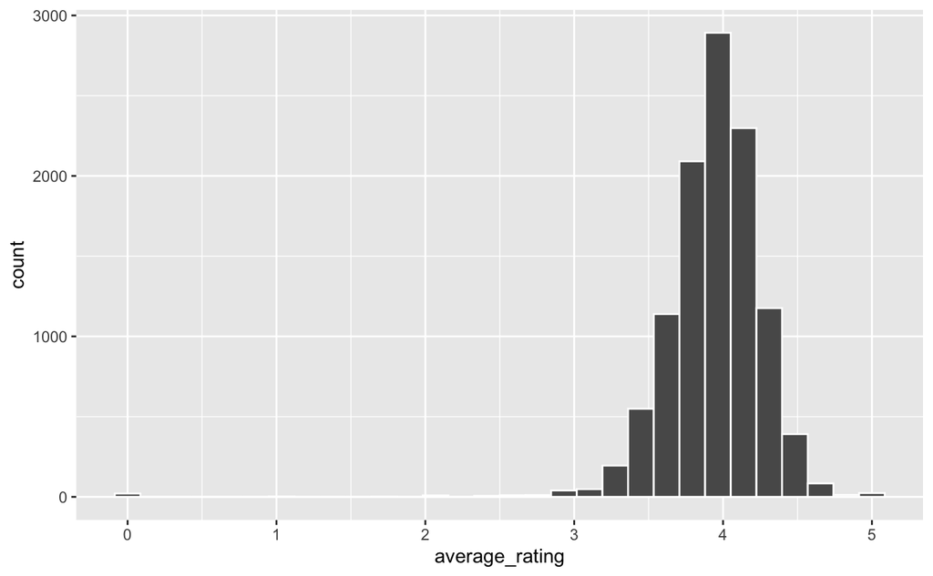

```r
books_tidy %>%
  ggplot(aes(x = average_rating)) +
  geom_histogram(col = "white")
```

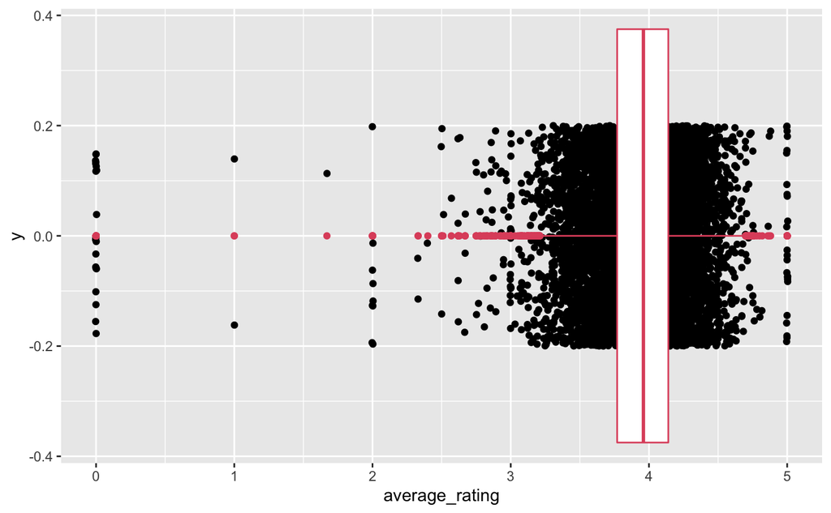

```r
books_tidy %>%
  ggplot(aes(x = average_rating)) +
  geom_jitter(aes(y = 0), height = 0.2) +
  geom_boxplot(colour = 2)
```

```r
NA
```

The data we have is from 2020 Good Reads We are going to test to see if the 2020 average rating is different from the 2016 average rating

The 2020 data is a **SAMPLE** the 2016 data is a **POPULATION**

```r
#2020 average rating
mean(books_tidy$average_rating)
```

```
[1] 3.937568
```

The 2016 average rating is 3.93 The 2020 average rating is 3.937568

We are going to set up 2 *competing hypotheses*

**Null** hypothesis : H0 $H_0$ > framed as the *skeptical* position > the hypothesis of: > no difference > no change > things are the same

Example: The average rating from 2020 is *not* difference form the average rating from 2016

**ALternative** hypothesis : H1 $H_1$ or $H_a$ > framed as the > the hypothesis of: > difference

Example: The average rating from 2020 *is* different form the average rating from 2016

Our 2 hypothesis must be: > mutually exclusive > exhaustive

$$H_0 : µ_{average\ rating} = 3.93$$

$$H_0 : µ_{average\ rating} \neq 3.93$$

Greek letters used to represent population parameters
$$\mu = population\ mean\\\\\\\
\pi = population\ proportion$$

```r
#2020 average rating
observed_stat <- mean(books_tidy$average_rating)
```

IS 2020 **significantly** different from 2016’s 3.93????

Steps of a hypothesis test:

> Step 1

*Before* we look at the data: > decide on our *significance level* (set a threshold - what counts as significant sets the error rate) > significance level (alpha level) is usually *0.05* > we can expect to wrongly reject H0 1:20 times

> Step 2

Calculate the statistic from the sample > in this example it is the *mean*

> Step 3

Create the sampling distribution - bootstrapping

*VERY IMPORTANT* when we create the sampling distribution we *assume that it is TRUE*

> Step 4

Compare our calculated statistic with the sampling distribution

If the calculated stat is far enough into the tail of our *Null* distribution we call it **significant** == **p-value**

> Step 5

If the p-value is < alpha > we *reject* H0 > find evidence in support of our H1

If the p-value is not < alpha > we *do not reject* H0 > failed to find evidence in support of our H1

# Hypothesis Testing with `infer`

```r
bootstrap_distn <- books_tidy %>%
  specify(response = average_rating) %>%
  generate(reps = 5000, type = "bootstrap") %>%
  calculate(stat = "mean")
```

```r
null_bootstrap_distn <- books_tidy %>%
  specify(response = average_rating) %>%
  hypothesise(null = "point", mu = 3.93) %>%
  generate(reps = 5000, type = "bootstrap") %>%
  calculate(stat = "mean")
```

```r
#2020 average rating
observed_stat <- mean(books_tidy$average_rating)
```

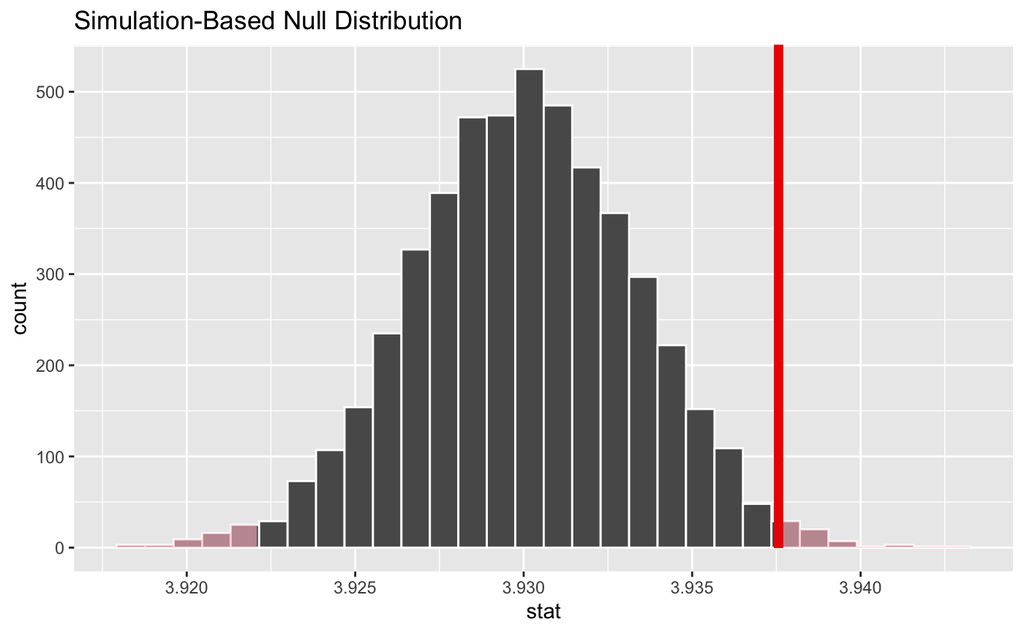

```r
# two-tailed test
null_bootstrap_distn %>%
  visualise(bins = 30) +
  shade_p_value(obs_stat = observed_stat, direction = "both")
```

# No direction specified

$$H_0 : µ_{average\ rating} \neq 3.93$$
# Get p-value

```r
p_value <- null_bootstrap_distn %>%
  get_p_value(obs_stat = observed_stat, direction = "both")

p_value
```

| p_value |
| --- |
| 0.0212 |

What does the p-value actually mean?

> How likely is it to see a result as extreme as your observed results, *if the null hypothesis is TRUE* ?

> If the null was TRUE, how weird would this data be?

> Extreme = less than alpha

**Don’t say** > The p value is the probability that H0 is correct

Result: Our observed stat of 3.9375679 is significantly different from out Null stat of 3.93, at an alpha level of 0.05 We therefore find evidence that the 2020 user rating mean is different to the 2016 user rating mean

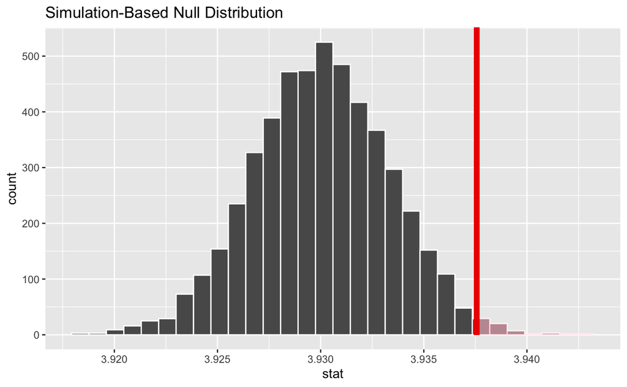

```r
# one-tailed test
null_bootstrap_distn %>%
  visualise(bins = 30) +
  shade_p_value(obs_stat = observed_stat, direction = "right")
```

# Direction specified

$$H_0 : µ_{average\ rating} > 3.93$$

Do books in Spanish have a mean(average_rating) significantly less than 3.96?

alpha = 0.05 H0: mu = 3.96 H1: mu < 3.96

```r
spanish_books <- books_tidy %>%
  filter(language_code == "spa")
```

```r
spanish_observed_stat
```

```
Response: average_rating (numeric)
```

| stat |
| --- |
| 3.943381 |

```r
spanish_null_distribution <- spanish_books %>%
  specify(response = average_rating) %>%
  hypothesise(null = "point", mu = 3.96) %>%
  generate(reps = 5000, type = "bootstrap") %>%
  calculate(stat = "mean")
```

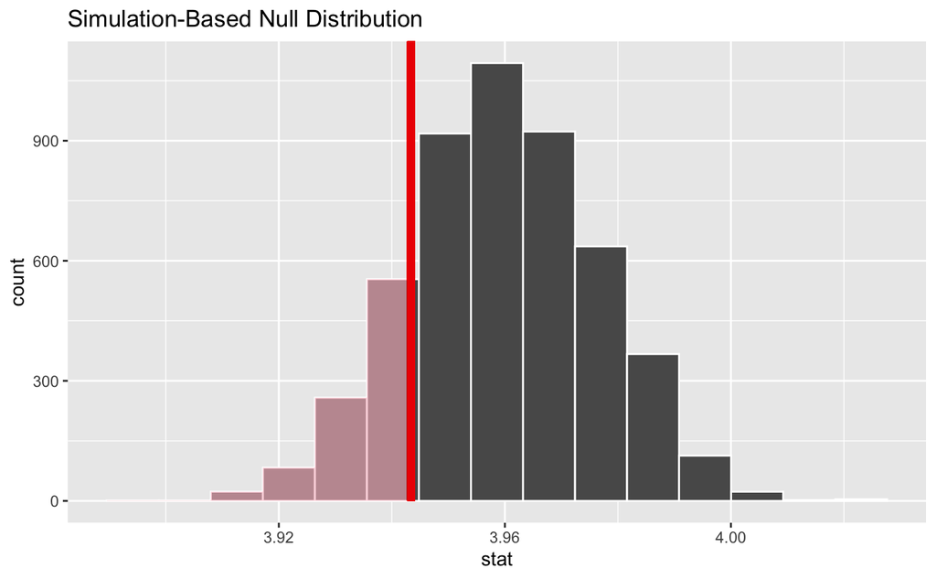

```r
spanish_null_distribution %>%
  visualise() +
  shade_p_value(obs_stat = spanish_observed_stat, direction = "left")
```

```r
spanish_p_value <- spanish_null_distribution %>%
  get_p_value(obs_stat = spanish_observed_stat, direction = "left")

spanish_p_value
```

| p_value |
| --- |
| 0.1646 |